# merge_CalMapper_PFIRS

2023-09-29

This script creates a merged list of treatments from both CalMapper and PFIRS with: - years 2020-2022 - outside NF land - filtered to AEPP threshold - buffered overlay method to account for PFIRS being point data

# Load data

```r
file = "Rdata/CalMapper_activities_fire_noNF.Rdata"
load(file)
#mapview(cm)
```

```r
file = "Rdata/PFIRS_2017-2022_pull2023_noNF.Rdata"
load(file)
#mapview(sf_noNF)
pfirs <- sf_noNF
remove(sf_noNF)
```

# Filter to years 2020-2022

## CalMapper

```r
cm <- cm %>%
  filter(YEAR %in% seq(2020, 2022))
```

## PFIRS

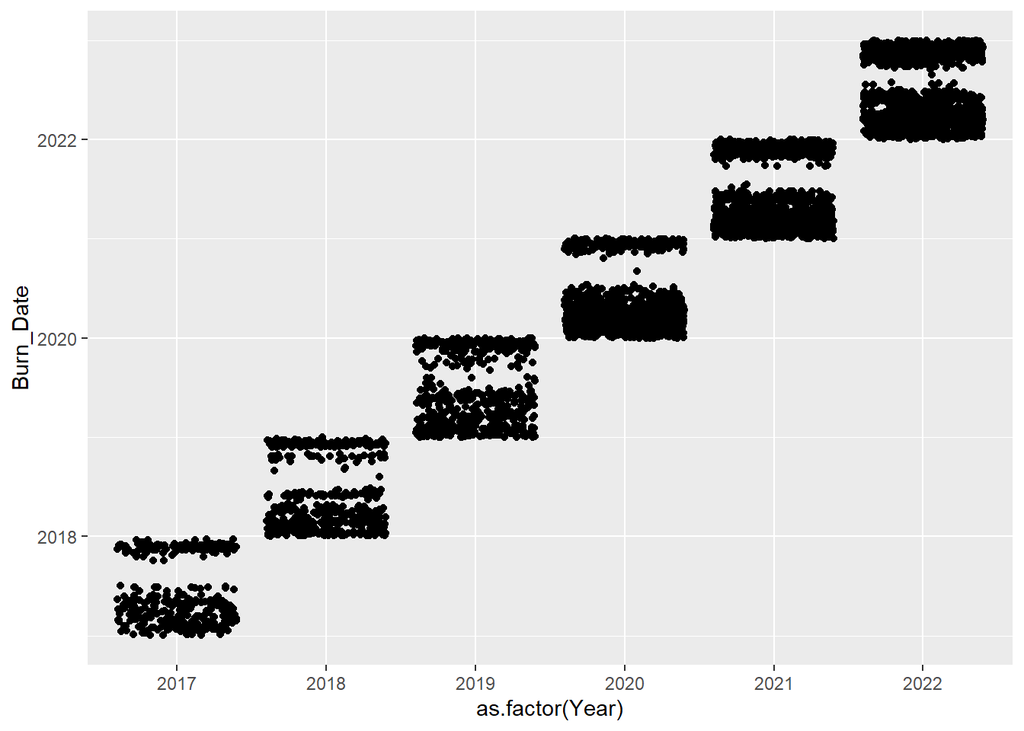

```r
pfirs %>%
  group_by(Year) %>%
  ggplot(aes(x = as.factor(Year), y = Burn_Date))+
  geom_point(position = position_jitter())
```

```r
pfirs <- pfirs %>%
  filter(Year %in% seq(2020, 2022))
```

# Filter by size according to AERR thresholds

## CalMapper

```r
cm %>%
  st_drop_geometry() %>%
  group_by(ACTIVITY_DESCRIPTION) %>%
  count()
```

```
## # A tibble: 3 × 2
## # Groups:   ACTIVITY_DESCRIPTION [3]
##   ACTIVITY_DESCRIPTION     n
##   <chr>                <int>
## 1 Broadcast Burn         512
## 2 Cultural Burning         4
## 3 Pile Burning          1202
```

```r
nrow_old <- nrow(cm)

cm <- cm %>%
  filter((ACTIVITY_DESCRIPTION == "Pile Burning" & TREATED_ACRES >= 25) | (ACTIVITY_DESCRIPTION %in% c("Broadcast Burn", "Cultural Burning") & TREATED_ACRES >= 50))

deleted_n <- nrow_old - nrow(cm)
print(paste("Deleted", deleted_n, "records below the size threshold"))
```

```
## [1] "Deleted 1418 records below the size threshold"
```

## PFIRS

```r
pfirs %>%
  st_drop_geometry() %>%
  group_by(Burn_Type) %>%
  count()
```

```
## # A tibble: 9 × 2
## # Groups:   Burn_Type [9]
##   Burn_Type               n
##   <chr>               <int>
## 1 Broadcast            1224
## 2 Hand Pile            1630
## 3 Hand Piles              1
## 4 Landing Pile           56
## 5 Machine Pile          882
## 6 Multiple Fuel Types    23
## 7 Multiple Fuels         14
## 8 UNK                    17
## 9 Unknown               266
```

### Add a column for “pile” or “broadcast” since the burn type column is messy

```r
pfirs <- pfirs %>%
  mutate(Burn_Type_Simple = case_when(
    Burn_Type %in% c("Hand Pile", "Hand Piles", "Landing Pile", "Landing Piles", "Machine Pile", "Machine Piles") ~ "Pile",
    Burn_Type == "Broadcast" ~ "Broadcast",
    Burn_Type %in% c("Multiple Fuel Types", "Multiple Fuels", "UNK", "Unknown") ~ "Unknown/Multiple",
    TRUE ~ NA
  ))
```

```r
pfirs %>%
  st_drop_geometry() %>%
  group_by(Burn_Type, Burn_Type_Simple) %>%
  count()
```

```
## # A tibble: 9 × 3
## # Groups:   Burn_Type, Burn_Type_Simple [9]
##   Burn_Type           Burn_Type_Simple     n
##   <chr>               <chr>            <int>
## 1 Broadcast           Broadcast         1224
## 2 Hand Pile           Pile              1630
## 3 Hand Piles          Pile                 1
## 4 Landing Pile        Pile                56
## 5 Machine Pile        Pile               882
## 6 Multiple Fuel Types Unknown/Multiple    23
## 7 Multiple Fuels      Unknown/Multiple    14
## 8 UNK                 Unknown/Multiple    17
## 9 Unknown             Unknown/Multiple   266
```

## Filter to burns within the AERR size thresholds

```r
nrow_old <- nrow(pfirs)

pfirs <- pfirs %>%
  filter((Burn_Type_Simple == "Pile" & Acres_Burned >= 25) | (Burn_Type_Simple %in% c("Broadcast", "Unknown/Multiple") & Acres_Burned >= 50))

deleted_n <- nrow_old - nrow(pfirs)
print(paste("Deleted", deleted_n, "records below the size threshold"))
```

```
## [1] "Deleted 3504 records below the size threshold"
```

# Sync up crs’s

```r
if(object.size(cm) > object.size(pfirs)){
  print("CalMapper is more GB than PFIRS")
}
```

```
## [1] "CalMapper is more GB than PFIRS"
```

```r
pfirs <- st_transform(pfirs, st_crs(cm))
```

# Add ID column to PFIRS

```r
pfirs <- pfirs %>%
  mutate(ID_PFIRS_CT = seq(1, nrow(pfirs)))
```

# Add Data_source column

```r
pfirs <- pfirs %>%
  mutate(Data_source = "PFIRS")
```

```r
cm <- cm %>%
  mutate(Data_source = "CalMapper")
```

# Find out how often reported acreage is pretty different from GIS acreage

```r
cm %>%
  mutate(gis_acres_treatment = as.numeric(st_area(cm)/4046.86)) %>%
  st_drop_geometry() %>%
  filter(TREATED_ACRES > 1.5*gis_acres_treatment) %>%
  nrow()
```

```
## [1] 13
```

```r
cm %>%
  mutate(gis_acres_treatment = as.numeric(st_area(cm)/4046.86)) %>%
  st_drop_geometry() %>%
  filter(gis_acres_treatment > 1.5*TREATED_ACRES) %>%
  nrow()
```

```
## [1] 266
```

```r
cm %>%
  mutate(gis_acres_treatment = as.numeric(st_area(cm)/4046.86)) %>%
  st_drop_geometry() %>%
  filter(gis_acres_treatment < 1.5*TREATED_ACRES & TREATED_ACRES < 1.5*gis_acres_treatment) %>%
  nrow()
```

```
## [1] 21
```

## Find a good example of GIS acreage way more than reported acreage

```r
cm %>%
  mutate(gis_acres_treatment = as.numeric(st_area(cm)/4046.86)) %>%
  st_drop_geometry() %>%
  filter(gis_acres_treatment > 20*TREATED_ACRES ) %>%
  select(AQ_ID, CALMAPPER_ID, gis_acres_treatment, TREATED_ACRES, ACTIVITY_DESCRIPTION)
```

```
##     AQ_ID      CALMAPPER_ID gis_acres_treatment TREATED_ACRES
## 1   64978 2500-2019-FPL-015            1342.101         45.00
## 2  156198 2500-2019-FPL-015            1342.101         44.50
## 3  264131 4600-2021-VMP-005           15351.617         63.22
## 4  380822 1200-2020-FPL-011            4407.100         98.00
## 5  380823 1200-2020-FPL-011            4407.100         62.60
## 6  380825 1200-2020-FPL-011            4407.100         76.80
## 7  380826 1200-2020-FPL-011            4407.100         97.67
## 8  277457 4200-2021-FHP-002            4751.457         55.00
## 9  214758 2400-2020-VMP-001            1797.509         80.00
## 10 214753 2400-2020-VMP-001            1797.509         50.00
## 11 214754 2400-2020-VMP-001            1797.509         80.00
## 12 214757 2400-2020-VMP-001            1797.509         60.00
## 13 232998 2100-2021-VMP-001            1363.991         40.00
## 14 266589 4600-2017-FPL-021            8279.826        179.20
```

[output cut: 35 more lines]

```r
cm %>%
  mutate(gis_acres_treatment = as.numeric(st_area(cm)/4046.86)) %>%
  st_drop_geometry() %>%
  filter(gis_acres_treatment > 20*TREATED_ACRES ) %>%
  select(AQ_ID, CALMAPPER_ID, gis_acres_treatment, TREATED_ACRES, ACTIVITY_DESCRIPTION) %>% filter(AQ_ID == 264131)
```

```
##    AQ_ID      CALMAPPER_ID gis_acres_treatment TREATED_ACRES
## 1 264131 4600-2021-VMP-005            15351.62         63.22
##   ACTIVITY_DESCRIPTION
## 1       Broadcast Burn
```

# Plot filtered data together

## Convert year columns to factors

```r
pfirs$Year <- as.factor(pfirs$Year)
cm$Year <- as.factor(cm$YEAR)
cm <- cm %>%
  select(-YEAR)
```

## Buffer PFIRS

```r
pfirs_buff <- st_buffer(pfirs, dist = 1000)
```

### Write

```r
pfirs_buff <- pfirs_buff %>%
  select(-REGION, -DIVISION, -STATEFP, -STATENS, -GEOID, -STUSPS, -NAME, -LSAD, -MTFCC, -FUNCSTAT, -ALAND, -AWATER, -INTPTLAT, -INTPTLON)
st_write(pfirs_buff, dsn = "shapefiles", layer = "pfirs_buffer", driver = "ESRI Shapefile", delete_layer = T)
```

```
## Deleting layer `pfirs_buffer' using driver `ESRI Shapefile'
## Writing layer `pfirs_buffer' to data source `shapefiles' using driver `ESRI Shapefile'
```

```
## Writing 609 features with 15 fields and geometry type Polygon.
```

### Plot using mapview

```r
st_crs(pfirs) == st_crs(cm)
```

```
## [1] TRUE
```

```r
# mapview(pfirs, zcol = "Year", col.regions = colors, alpha.regions = 0.5)+
#   mapview(cm, zcol = "Year", col.regions = colors,  alpha.regions = 0.5)+
#   mapview(pfirs_buff, zcol = "Year", col.regions = colors, alpha.regions = 0.3)
```

# Plot without duplicates removed at all

## Calculate agreage of each, by year

```r
table <- pfirs %>%
  st_drop_geometry() %>%
  group_by(Year) %>%
  summarize(ac = sum(Acres_Burned)) %>%
  mutate(source = "pfirs")
table
```

```
## # A tibble: 3 × 3
##   Year      ac source
##   <fct>  <dbl> <chr>
## 1 2020  53463. pfirs
## 2 2021  27441. pfirs
## 3 2022  41651. pfirs
```

```r
table_method0 <- cm %>%
  st_drop_geometry() %>%
  group_by(Year) %>%
  summarize(ac = sum(TREATED_ACRES)) %>%
  mutate(source = "cm") %>%
  full_join(table)
table_method0
```

```
## # A tibble: 6 × 3
##   Year      ac source
##   <fct>  <dbl> <chr>
## 1 2020  12859. cm
## 2 2021  31811. cm
## 3 2022  27296. cm
## 4 2020  53463. pfirs
## 5 2021  27441. pfirs
## 6 2022  41651. pfirs
```

## Plot

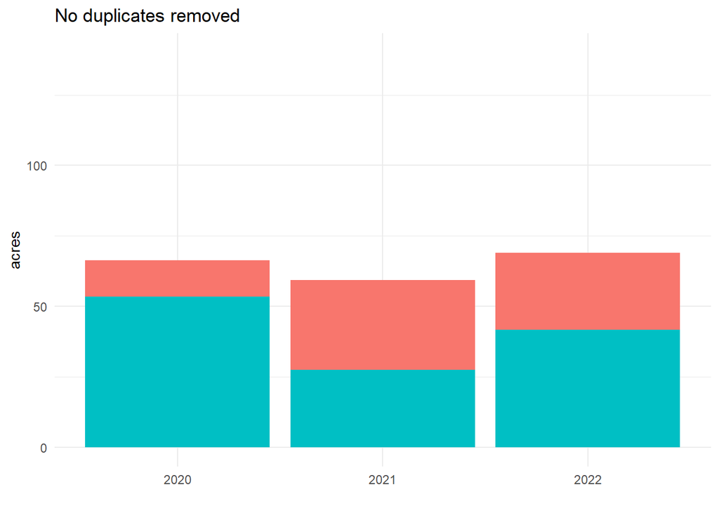

```r
plot_method0 <- ggplot(table_method0 %>% group_by(source))+
  geom_col(aes(x = Year, y = ac/1000, group = source, fill = source))+
  ylab("acres")+
  ggtitle("No duplicates removed")+
  theme_minimal()+
  guides(fill = "none")+
  ylim(c(0,140))+
  xlab("")
plot_method0
```

# Find duplicates

## Rename columns with identifier for source

```r
pfirs_buff_dups <- pfirs_buff %>%
  rename(Year_pfirs = Year) %>%
  rename(Date_pfirs = Burn_Date) %>%
  rename(acres_pfirs = Acres_Burned) %>%
  rename(Agency_pfirs = Agency)
```

```r
cm_dups <- cm %>%
  ungroup %>%
  rename(Year_cm = Year) %>%
  rename(ACTIVITY_START_cm = ACTIVITY_START) %>%
  rename(ACTIVITY_END_cm = ACTIVITY_END) %>%
  rename(ID_CM_Trt = AQ_ID) %>%
  rename(acres_cm = TREATED_ACRES) %>%
  rename(Agency_cm = AGENCY_NAME) %>%
  rename()
```

## Spatial overlay

```r
dups <- st_intersection(pfirs_buff_dups, cm_dups)
```

## Filter `dups` to only rows where dates are THE SAME between the two data sets

### Filter to same year

```r
dups <- dups %>%
  filter(Year_pfirs == Year_cm)
```

### Look at date differences

```r
dups <- dups %>%
  mutate(diff_dates_start = difftime(Date_pfirs, ACTIVITY_START_cm, units = "days")) %>%
  mutate(diff_dates_end = difftime(Date_pfirs, ACTIVITY_END_cm, units = "days"))
```

## Remove duplicates with exact date match

```r
dups_daily <- dups %>%
  filter(Date_pfirs >= ACTIVITY_START_cm & Date_pfirs <= ACTIVITY_END_cm)
```

#### Check

```r
dups_daily %>%
  select(Date_pfirs, ACTIVITY_START_cm, ACTIVITY_END_cm) %>%
  st_drop_geometry() %>%
  tail()
```

```
## # A tibble: 6 × 3
##   Date_pfirs          ACTIVITY_START_cm ACTIVITY_END_cm
##   <dttm>              <date>            <date>
## 1 2022-10-26 00:00:00 2022-10-25        2022-10-26
## 2 2022-10-04 00:00:00 2022-10-04        2022-10-05
## 3 2022-10-04 00:00:00 2022-10-04        2022-10-05
## 4 2022-11-25 00:00:00 2022-11-25        2022-11-25
## 5 2022-10-27 00:00:00 2022-10-27        2022-10-27
## 6 2022-10-13 00:00:00 2022-10-13        2022-10-13
```

## Reorder columns

```r
dups_daily <- dups_daily %>%
  select(Burn_Unit, ACTIVITY_NAME, Date_pfirs, ACTIVITY_START_cm, ACTIVITY_END_cm, acres_pfirs, acres_cm, Agency_cm, Agency_pfirs, Burn_Type_Simple, ACTIVITY_DESCRIPTION, Burn_Type_Simple, everything())
```

```r
print(paste("There are ", nrow(dups_daily), "rows that are duplicated."))
```

```
## [1] "There are  168 rows that are duplicated."
```

```r
print(paste("-  Of those, there are ", length(unique(dups_daily$ID_PFIRS_CT)), "unique PFIRS records"))
```

```
## [1] "-  Of those, there are  132 unique PFIRS records"
```

```r
print(paste("-  and ", length(unique(dups_daily$ID_CM_Trt)), "unique CalMapper records"))
```

```
## [1] "-  and  96 unique CalMapper records"
```

# Handle Duplicates

## Method 1: Remove PFIRS points

### Remove duplicates from PFIRS

```r
pfirs_no_dups_daily <- pfirs %>%
  filter(!ID_PFIRS_CT %in% dups_daily$ID_PFIRS_CT)
```

### Combine pfirs and CalMapper

#### Sync column names

```r
cm_merge <- cm %>%
  rename(Agency = AGENCY_NAME,
          Acres_Burned = TREATED_ACRES,
         Burn_Type_Simple = ACTIVITY_DESCRIPTION) %>%
  select(Data_source, TREATMENT_NAME, Acres_Burned, Burn_Type_Simple, ACTIVITY_START, ACTIVITY_END, Agency, everything()) %>%
  mutate(gis_acres_treatment = as.numeric(st_area(cm)/4046.86)) %>%
  st_drop_geometry()
```

```r
pfirs_merge <- pfirs_no_dups_daily %>%
  rename(TREATMENT_NAME = Burn_Unit) %>%
  st_drop_geometry() %>%
  select(Data_source, TREATMENT_NAME, Acres_Burned, Burn_Type_Simple, Burn_Date, Agency, Burn_Type, everything())
```

#### Merge

```r
merged_method1 <- full_join(cm_merge, pfirs_merge)
```

[output not shown]

```r
nrow(pfirs_merge)+nrow(cm_merge) == nrow(merged_method1)
```

```
## [1] TRUE
```

```r
merged_method1 <- merged_method1 %>%
  select(Data_source, TREATMENT_NAME, Acres_Burned, Burn_Type_Simple, ACTIVITY_START, ACTIVITY_END, Burn_Date, Agency, everything()) %>%
  arrange(TREATMENT_NAME)
```

#### Save

```r
write_excel_csv(merged_method1, file = "excel/CalMapper_PFIRS_Method1.xls")
```

### Plot acreage

```r
table_method1 <- merged_method1 %>%
  group_by(Year, Data_source) %>%
  summarize(acres = sum(Acres_Burned))
```

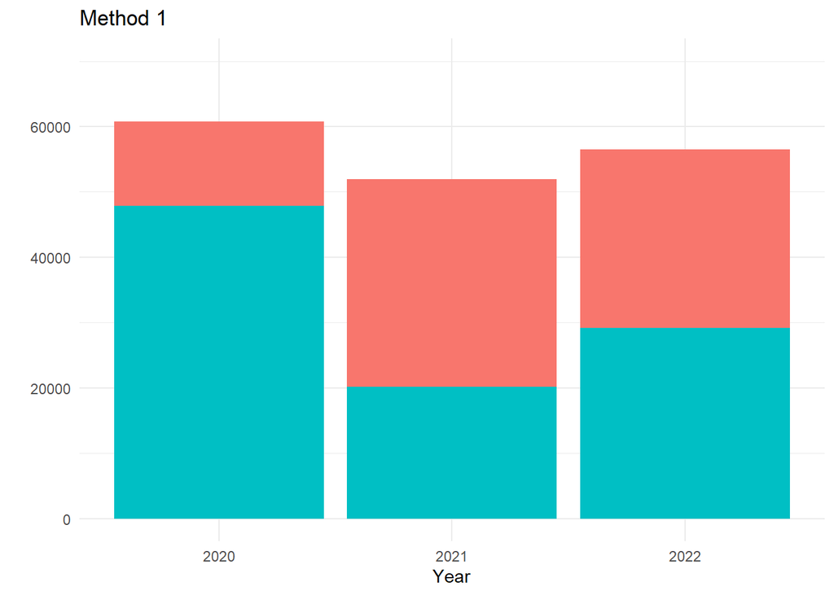

```r
plot_method1 <- table_method1 %>%
  ggplot()+
  geom_col(aes(x = Year, y = acres, fill = Data_source))+
  theme_minimal()+
  ggtitle("Method 1")+
  ylim(c(0,70000))+
  guides(fill = "none")+
  ylab("")
plot_method1
```

## Method 2: Remove whichever has the lower acreage

#### Sync column names

```r
cm_dup <- dups_daily %>%
  st_drop_geometry() %>%
  select(ID_CM_Trt) %>%
  distinct()
cm_dup
```

```
## # A tibble: 96 × 1
##    ID_CM_Trt
##        <int>
##  1    224350
##  2     74270
##  3     98268
##  4    296099
##  5    241317
##  6    131270
##  7    292288
##  8    265633
##  9    104667
## 10    134741
## # ℹ 86 more rows
```

For the CalMapper polygons with multiple overlapping PFIRS points, add up the acreage in the PFIRS points. If the total acreage is greater than the treated acreage in CM, then delete the CM polygon. Otherwise, delete the PFIRS points.

```r
count = 0
cm_merge <- cm %>%
  ungroup() %>%
  mutate(gis_acres_treatment = as.numeric(st_area(cm)/4046.86)) %>%
  st_drop_geometry()
pfirs_merge <- pfirs %>% ungroup() %>% st_drop_geometry()
for(i in 1:nrow(cm_dup)){
  cm_ID_i <- cm_dup[i,1] %>% unlist()
  test <- dups_daily %>% filter(ID_CM_Trt == cm_ID_i)
  if(nrow(test)==1){
    count = count + 1
    if(test$acres_cm >= test$acres_pfirs){
      pfirs_merge <- pfirs_merge %>%
        filter(!ID_PFIRS_CT %in% test$ID_PFIRS_CT)
    } else{
      cm_merge <- cm_merge %>%
        filter(AQ_ID != cm_ID_i)
      print("deleted CalMapper")
    }
  } else if (nrow(test)>1){
    if(test$acres_cm[1] >= sum(test$acres_pfirs)){
      pfirs_merge <- pfirs_merge %>%
        filter(!ID_PFIRS_CT %in% test$ID_PFIRS_CT)
      print("deleted multiple PFIRS")
      print(test$ID_PFIRS_CT)
    } else{
      cm_merge <- cm_merge %>%
        filter(AQ_ID != cm_ID_i)
      print("deleted CalMapper")
    }
  }
}
```

```
## [1] "deleted CalMapper"
## [1] "deleted CalMapper"
## [1] "deleted CalMapper"
## [1] "deleted CalMapper"
## [1] "deleted multiple PFIRS"
## [1] 513 514 515 516
## [1] "deleted CalMapper"
## [1] "deleted CalMapper"
## [1] "deleted CalMapper"
## [1] "deleted CalMapper"
## [1] "deleted CalMapper"
## [1] "deleted CalMapper"
## [1] "deleted CalMapper"
## [1] "deleted multiple PFIRS"
## [1] 191 193
```

[output cut: 57 more lines]

### Troubleshoot for ID_CM_Trt == 298115 and 307233

```r
cm_ID_i <- 298115
test <- dups_daily %>% filter(ID_CM_Trt == cm_ID_i)
if(nrow(test)==1){
  count = count + 1
  if(test$acres_cm >= test$acres_pfirs){
    pfirs_merge <- pfirs_merge %>%
      filter(!ID_PFIRS_CT %in% test$ID_PFIRS_CT)
  } else{
    cm_merge <- cm_merge %>%
      filter(AQ_ID != cm_ID_i)
    print("deleted CalMapper")
  }
} else if (nrow(test)>1){
  if(test$acres_cm[1] >= sum(test$acres_pfirs)){
    pfirs_merge <- pfirs_merge %>%
      filter(!ID_PFIRS_CT %in% test$ID_PFIRS_CT)
    print("deleted multiple PFIRS")
    print(test$ID_PFIRS_CT)
  } else{
    cm_merge <- cm_merge %>%
      filter(AQ_ID != cm_ID_i)
    print("deleted CalMapper")
  }
}
```

```
## [1] "deleted multiple PFIRS"
## [1] 517 518
```

```r
print(paste("Out of all the duplicates,", count, "are 1:1 duplicates, and", nrow(cm_dup)-count, "CalMapper ID's are more complicated"))
```

```
## [1] "Out of all the duplicates, 65 are 1:1 duplicates, and 31 CalMapper ID's are more complicated"
```

```r
print(paste("There were", nrow(cm)-nrow(cm_merge), "rows deleted from CalMapper"))
```

```
## [1] "There were 48 rows deleted from CalMapper"
```

```r
print(paste("There were", nrow(pfirs)-nrow(pfirs_merge), "rows deleted from PFIRS"))
```

```
## [1] "There were 67 rows deleted from PFIRS"
```

### Merge

```r
cm_merge <- cm_merge %>%
  rename(Agency = AGENCY_NAME,
          Acres_Burned = TREATED_ACRES,
         Burn_Type_Simple = ACTIVITY_DESCRIPTION) %>%
  select(Data_source, TREATMENT_NAME, Acres_Burned, Burn_Type_Simple, ACTIVITY_START, ACTIVITY_END, Agency, everything()) %>%
  st_drop_geometry()
```

```r
pfirs_merge <- pfirs_merge %>%
  rename(TREATMENT_NAME = Burn_Unit) %>%
  st_drop_geometry() %>%
  select(Data_source, TREATMENT_NAME, Acres_Burned, Burn_Type_Simple, Burn_Date, Agency, Burn_Type, everything())
```

```r
merged_method2 <- full_join(cm_merge, pfirs_merge)
```

[output not shown]

```r
nrow(pfirs_merge)+nrow(cm_merge) == nrow(merged_method2)
```

```
## [1] TRUE
```

### Plot acreage

```r
table_method2 <- merged_method2 %>%
  group_by(Year, Data_source) %>%
  summarize(acres = sum(Acres_Burned))
```

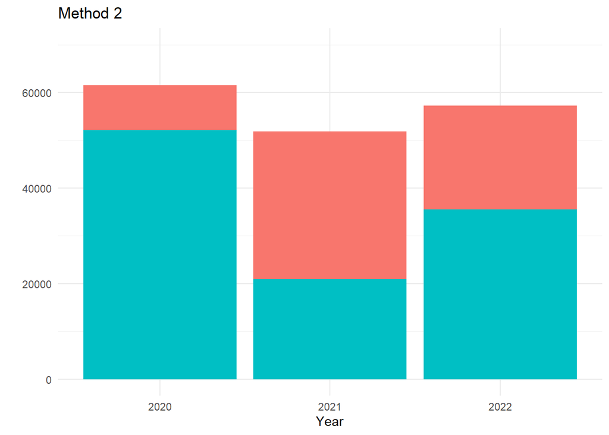

```r
plot_method2 <- table_method2 %>%
  ggplot()+
  geom_col(aes(x = Year, y = acres, fill = Data_source))+
  theme_minimal()+
  ggtitle("Method 2")+
  ylim(c(0,70000))+
  ylab("")+
    guides(fill = "none")
plot_method2
```

## Method 3: Method 2 but with a 30-day buffer

#### Filter by date

```r
dups_monthly <- dups %>%
  filter((Date_pfirs >= ACTIVITY_START_cm & Date_pfirs <= ACTIVITY_END_cm) | abs(diff_dates_start)<30 | abs(diff_dates_end)<30)
```

#### Create list of CM unique records in `dups_monthly`

```r
cm_dup <- dups_monthly %>%
  st_drop_geometry() %>%
  select(ID_CM_Trt) %>%
  distinct()
cm_dup
```

```
## # A tibble: 109 × 1
##    ID_CM_Trt
##        <int>
##  1    224350
##  2     67302
##  3     74270
##  4     98268
##  5    296099
##  6    241317
##  7    131270
##  8    264131
##  9    292288
## 10    265633
## # ℹ 99 more rows
```

For the CalMapper polygons with multiple overlapping PFIRS points, add up the acreage in the PFIRS points. If the total acreage is greater than the treated acreage in CM, then delete the CM polygon. Otherwise, delete the PFIRS points.

```r
count = 0

cm_merge <- cm %>%
  ungroup() %>%
  mutate(gis_acres_treatment = as.numeric(st_area(cm)/4046.86)) %>%
  st_drop_geometry()

pfirs_merge <- pfirs %>% ungroup() %>% st_drop_geometry()

for(i in 1:nrow(cm_dup)){
  cm_ID_i <- cm_dup[i,1] %>% unlist()
  test <- dups_monthly %>% filter(ID_CM_Trt == cm_ID_i)
  if(nrow(test)==1){
    count = count + 1
    if(test$acres_cm >= test$acres_pfirs){
      pfirs_merge <- pfirs_merge %>%
        filter(!ID_PFIRS_CT %in% test$ID_PFIRS_CT)
    } else{
      cm_merge <- cm_merge %>%
        filter(AQ_ID != cm_ID_i)
      print("deleted CalMapper")
    }
  } else if (nrow(test)>1){
    if(test$acres_cm[1] >= sum(test$acres_pfirs)){
      pfirs_merge <- pfirs_merge %>%
        filter(!ID_PFIRS_CT %in% test$ID_PFIRS_CT)
      print("deleted multiple PFIRS")
      print(test$ID_PFIRS_CT)
    } else{
      cm_merge <- cm_merge %>%
        filter(AQ_ID != cm_ID_i)
      print("deleted CalMapper")
    }
  }
}
```

```
## [1] "deleted CalMapper"
## [1] "deleted CalMapper"
## [1] "deleted CalMapper"
## [1] "deleted CalMapper"
## [1] "deleted CalMapper"
## [1] "deleted CalMapper"
## [1] "deleted multiple PFIRS"
## [1] 513 514 515 516
## [1] "deleted CalMapper"
## [1] "deleted multiple PFIRS"
## [1] 139 152
## [1] "deleted CalMapper"
## [1] "deleted multiple PFIRS"
## [1] 276 295
## [1] "deleted CalMapper"
```

[output cut: 69 more lines]

### Test

```r
test <- dups_monthly %>% filter(ID_CM_Trt == cm_ID_i)
if(nrow(test)==1){
  count = count + 1
  if(test$acres_cm >= test$acres_pfirs){
    pfirs_merge <- pfirs_merge %>%
      filter(!ID_PFIRS_CT %in% test$ID_PFIRS_CT)
  } else{
    cm_merge <- cm_merge %>%
      filter(AQ_ID != cm_ID_i)
    print("deleted CalMapper")
  }
} else if (nrow(test)>1){
  if(test$acres_cm[1] >= sum(test$acres_pfirs)){
    pfirs_merge <- pfirs_merge %>%
      filter(!ID_PFIRS_CT %in% test$ID_PFIRS_CT)
    print("deleted multiple PFIRS")
    print(test$ID_PFIRS_CT)
  } else{
    cm_merge <- cm_merge %>%
      filter(AQ_ID != cm_ID_i)
    print("deleted CalMapper")
  }
}
```

```r
print(paste("Out of all the duplicates,", count, "are 1:1 duplicates, and", nrow(cm_dup)-count, "CalMapper ID's are more complicated"))
```

```
## [1] "Out of all the duplicates, 60 are 1:1 duplicates, and 49 CalMapper ID's are more complicated"
```

```r
print(paste("There were", nrow(cm)-nrow(cm_merge), "rows deleted from CalMapper"))
```

```
## [1] "There were 64 rows deleted from CalMapper"
```

```r
print(paste("There were", nrow(pfirs)-nrow(pfirs_merge), "rows deleted from PFIRS"))
```

```
## [1] "There were 58 rows deleted from PFIRS"
```

### Merge

```r
cm_merge <- cm_merge %>%
  rename(Agency = AGENCY_NAME,
          Acres_Burned = TREATED_ACRES,
         Burn_Type_Simple = ACTIVITY_DESCRIPTION) %>%
  select(Data_source, TREATMENT_NAME, Acres_Burned, Burn_Type_Simple, ACTIVITY_START, ACTIVITY_END, Agency, everything()) %>%
  st_drop_geometry()
```

```r
pfirs_merge <- pfirs_merge %>%
  rename(TREATMENT_NAME = Burn_Unit) %>%
  st_drop_geometry() %>%
  select(Data_source, TREATMENT_NAME, Acres_Burned, Burn_Type_Simple, Burn_Date, Agency, Burn_Type, everything())
```

```r
merged_method3 <- full_join(cm_merge, pfirs_merge)
```

[output not shown]

```r
nrow(pfirs_merge)+nrow(cm_merge) == nrow(merged_method3)
```

```
## [1] TRUE
```

## Spot check

### Example 2

```r
merged_method1 %>%
 filter(TREATMENT_NAME %in% c("CD", "Pasture", "West Ridgetop") | ACTIVITY_ID ==27381) %>%
  select(1:7, Burn_Date)
```

```
##   Data_source           TREATMENT_NAME Acres_Burned Burn_Type_Simple
## 1   CalMapper 2022 Hillside Ranch Burn        242.8   Broadcast Burn
## 2   CalMapper 2022 Hillside Ranch Burn         50.0   Broadcast Burn
##   ACTIVITY_START ACTIVITY_END Burn_Date
## 1     2022-09-30   2022-09-30      <NA>
## 2     2022-10-19   2022-10-19      <NA>
```

```r
merged_method2 %>%
 filter(TREATMENT_NAME %in% c("CD", "Pasture", "West Ridgetop") | ACTIVITY_ID ==27381) %>%
  select(1:6, Burn_Date)
```

```
##   Data_source           TREATMENT_NAME Acres_Burned Burn_Type_Simple
## 1   CalMapper 2022 Hillside Ranch Burn        242.8   Broadcast Burn
## 2       PFIRS            West Ridgetop         51.2        Broadcast
##   ACTIVITY_START ACTIVITY_END  Burn_Date
## 1     2022-09-30   2022-09-30       <NA>
## 2           <NA>         <NA> 2022-10-19
```

```r
merged_method3 %>%
  filter(TREATMENT_NAME %in% c("CD", "Pasture", "West Ridgetop") | ACTIVITY_ID ==27381) %>%
  select(1:6, Burn_Date)
```

```
##   Data_source TREATMENT_NAME Acres_Burned Burn_Type_Simple ACTIVITY_START
## 1       PFIRS             CD         73.0        Broadcast           <NA>
## 2       PFIRS        Pasture        167.0        Broadcast           <NA>
## 3       PFIRS  West Ridgetop         51.2        Broadcast           <NA>
##   ACTIVITY_END  Burn_Date
## 1         <NA> 2022-09-30
## 2         <NA> 2022-09-30
## 3         <NA> 2022-10-19
```

### Example 3

```r
merged_method1 %>%
 filter(TREATMENT_NAME %in% c("Rx-North-076-HUU Hunt Ranch 19 VMP", "Hunt VMP Units 4 & 5") | AQ_ID == 292291 | ID_PFIRS_CT == 519) %>%
  select(1:6, Burn_Date)
```

```
##   Data_source   TREATMENT_NAME Acres_Burned Burn_Type_Simple ACTIVITY_START
## 1   CalMapper Units 4 & 5 2022           80   Broadcast Burn     2022-09-30
##   ACTIVITY_END Burn_Date
## 1   2022-09-30      <NA>
```

```r
merged_method2 %>%
 filter(TREATMENT_NAME %in% c("Rx-North-076-HUU Hunt Ranch 19 VMP", "Hunt VMP Units 4 & 5") | AQ_ID == 292291 | ID_PFIRS_CT == 519) %>%
  select(1:6, Burn_Date)
```

```
##   Data_source   TREATMENT_NAME Acres_Burned Burn_Type_Simple ACTIVITY_START
## 1   CalMapper Units 4 & 5 2022           80   Broadcast Burn     2022-09-30
##   ACTIVITY_END Burn_Date
## 1   2022-09-30      <NA>
```

```r
merged_method3 %>%
 filter(TREATMENT_NAME %in% c("Rx-North-076-HUU Hunt Ranch 19 VMP", "Hunt VMP Units 4 & 5") | AQ_ID == 292291 | ID_PFIRS_CT == 519) %>%
  select(1:6, Burn_Date)
```

```
##   Data_source   TREATMENT_NAME Acres_Burned Burn_Type_Simple ACTIVITY_START
## 1   CalMapper Units 4 & 5 2022           80   Broadcast Burn     2022-09-30
##   ACTIVITY_END Burn_Date
## 1   2022-09-30      <NA>
```

### Example 5

```r
merged_method1 %>%
  filter(TREATMENT_NAME == "2022-Johnson VMP Block1" | TREATMENT_NAME == "2022_Johnson Burn Block 1") %>%
  select(1:7, Burn_Date)
```

```
##   Data_source            TREATMENT_NAME Acres_Burned Burn_Type_Simple
## 1       PFIRS   2022-Johnson VMP Block1          160 Unknown/Multiple
## 2   CalMapper 2022_Johnson Burn Block 1          162   Broadcast Burn
##   ACTIVITY_START ACTIVITY_END  Burn_Date
## 1           <NA>         <NA> 2022-11-15
## 2     2022-11-17   2022-11-18       <NA>
```

```r
merged_method2 %>%
  filter(TREATMENT_NAME == "2022-Johnson VMP Block1" | TREATMENT_NAME == "2022_Johnson Burn Block 1") %>%
  select(1:7, Burn_Date)
```

```
##   Data_source            TREATMENT_NAME Acres_Burned Burn_Type_Simple
## 1   CalMapper 2022_Johnson Burn Block 1          162   Broadcast Burn
## 2       PFIRS   2022-Johnson VMP Block1          160 Unknown/Multiple
##   ACTIVITY_START ACTIVITY_END   Agency  Burn_Date
## 1     2022-11-17   2022-11-18 CAL FIRE       <NA>
## 2           <NA>         <NA> CAL FIRE 2022-11-15
```

```r
merged_method3 %>%
  filter(TREATMENT_NAME == "2022-Johnson VMP Block1" | TREATMENT_NAME == "2022_Johnson Burn Block 1") %>%
  select(1:7, Burn_Date)
```

```
##   Data_source            TREATMENT_NAME Acres_Burned Burn_Type_Simple
## 1   CalMapper 2022_Johnson Burn Block 1          162   Broadcast Burn
##   ACTIVITY_START ACTIVITY_END   Agency Burn_Date
## 1     2022-11-17   2022-11-18 CAL FIRE      <NA>
```

### Example 6

```r
merged_method1 %>%
  filter(TREATMENT_NAME == "UNIT 7" | CALMAPPER_ID == "2600-2020-VMP-001") %>%
  select(1:6, Burn_Date)
```

```
##   Data_source      TREATMENT_NAME Acres_Burned Burn_Type_Simple ACTIVITY_START
## 1   CalMapper Bogus VMP Broadcast       560.00   Broadcast Burn     2022-10-06
## 2   CalMapper Bogus VMP Broadcast        50.08   Broadcast Burn     2022-10-18
## 3       PFIRS              UNIT 7        50.00        Broadcast           <NA>
##   ACTIVITY_END  Burn_Date
## 1   2022-10-08       <NA>
## 2   2022-10-18       <NA>
## 3         <NA> 2022-10-19
```

```r
merged_method2 %>%
  filter(TREATMENT_NAME == "UNIT 7" | CALMAPPER_ID == "2600-2020-VMP-001") %>%
  select(1:6, Burn_Date)
```

```
##   Data_source      TREATMENT_NAME Acres_Burned Burn_Type_Simple ACTIVITY_START
## 1   CalMapper Bogus VMP Broadcast       560.00   Broadcast Burn     2022-10-06
## 2   CalMapper Bogus VMP Broadcast        50.08   Broadcast Burn     2022-10-18
## 3       PFIRS              UNIT 7        50.00        Broadcast           <NA>
##   ACTIVITY_END  Burn_Date
## 1   2022-10-08       <NA>
## 2   2022-10-18       <NA>
## 3         <NA> 2022-10-19
```

```r
merged_method3 %>%
  filter(TREATMENT_NAME == "UNIT 7" | CALMAPPER_ID == "2600-2020-VMP-001") %>%
  select(1:6, Burn_Date)
```

```
##   Data_source      TREATMENT_NAME Acres_Burned Burn_Type_Simple ACTIVITY_START
## 1   CalMapper Bogus VMP Broadcast       560.00   Broadcast Burn     2022-10-06
## 2   CalMapper Bogus VMP Broadcast        50.08   Broadcast Burn     2022-10-18
##   ACTIVITY_END Burn_Date
## 1   2022-10-08      <NA>
## 2   2022-10-18      <NA>
```

### Example 8

```r
merged_method1 %>%
  filter(ID_PFIRS_CT %in% c(39, 42, 44) |AQ_ID %in% c("69460", "69461")) %>%
  select(1:6, Burn_Date)
```

```
##   Data_source                         TREATMENT_NAME Acres_Burned
## 1       PFIRS Cal Fire Ukiah Eastern Hills Broadcast          200
## 2   CalMapper         N-05-19 Ukiah Eastside Rx Fire          150
## 3   CalMapper         N-05-19 Ukiah Eastside Rx Fire          208
##   Burn_Type_Simple ACTIVITY_START ACTIVITY_END  Burn_Date
## 1        Broadcast           <NA>         <NA> 2020-02-12
## 2   Broadcast Burn     2020-02-10   2020-02-10       <NA>
## 3   Broadcast Burn     2020-02-11   2020-02-11       <NA>
```

```r
merged_method2 %>%
  filter(ID_PFIRS_CT %in% c(39, 42, 44) |AQ_ID %in% c("69460", "69461")) %>%
  select(1:6, Burn_Date)
```

```
##   Data_source                         TREATMENT_NAME Acres_Burned
## 1       PFIRS Cal Fire Ukiah Eastern Hills Broadcast          190
## 2       PFIRS Cal Fire Ukiah Eastern Hills Broadcast          450
## 3       PFIRS Cal Fire Ukiah Eastern Hills Broadcast          200
##   Burn_Type_Simple ACTIVITY_START ACTIVITY_END  Burn_Date
## 1        Broadcast           <NA>         <NA> 2020-02-10
## 2        Broadcast           <NA>         <NA> 2020-02-11
## 3        Broadcast           <NA>         <NA> 2020-02-12
```

```r
merged_method3 %>%
  filter(ID_PFIRS_CT %in% c(39, 42, 44) |AQ_ID %in% c("69460", "69461")) %>%
  select(1:6, Burn_Date)
```

```
##   Data_source                         TREATMENT_NAME Acres_Burned
## 1       PFIRS Cal Fire Ukiah Eastern Hills Broadcast          190
## 2       PFIRS Cal Fire Ukiah Eastern Hills Broadcast          450
## 3       PFIRS Cal Fire Ukiah Eastern Hills Broadcast          200
##   Burn_Type_Simple ACTIVITY_START ACTIVITY_END  Burn_Date
## 1        Broadcast           <NA>         <NA> 2020-02-10
## 2        Broadcast           <NA>         <NA> 2020-02-11
## 3        Broadcast           <NA>         <NA> 2020-02-12
```

### Plot acreage

```r
table_method3 <- merged_method3 %>%
  group_by(Year, Data_source) %>%
  summarize(acres = sum(Acres_Burned))
```

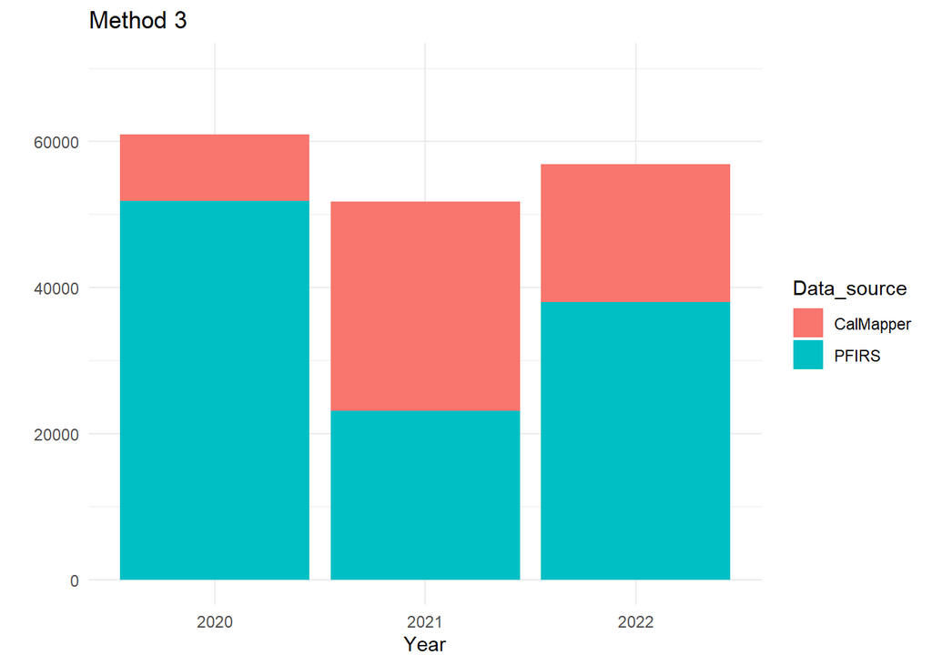

```r
plot_method3 <- table_method3 %>%
  ggplot()+
  geom_col(aes(x = Year, y = acres, fill = Data_source))+
  theme_minimal()+
  ggtitle("Method 3")+
  ylim(c(0,70000))+
  ylab("")
plot_method3
```

# Plot bar charts side-by-side

## Add numeric labels

### Method 0

```r
table_method0_a <- table_method0 %>%
  select(Year, source, ac) %>%
  group_by(Year) %>%
  mutate(total = sum(ac) %>% round(-2))
table_method0_a
```

```
## # A tibble: 6 × 4
## # Groups:   Year [3]
##   Year  source     ac total
##   <fct> <chr>   <dbl> <dbl>
## 1 2020  cm     12859. 66300
## 2 2021  cm     31811. 59300
## 3 2022  cm     27296. 68900
## 4 2020  pfirs  53463. 66300
## 5 2021  pfirs  27441. 59300
## 6 2022  pfirs  41651. 68900
```

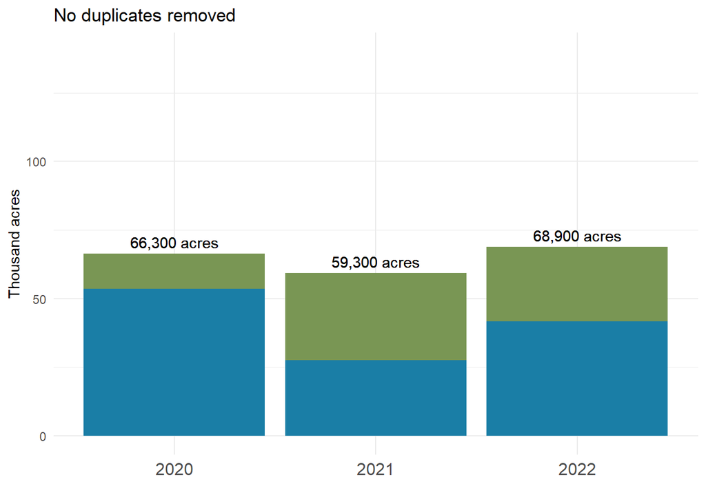

```r
plot_method0_a <- plot_method0+
  geom_text(data = table_method0_a, aes(x = Year, y = total/1000, label = paste(comma(total), "acres")), vjust = -0.5)+
  scale_fill_manual(values = c("#799654", "#1A7EA6"))+
  xlab("")+
  ylab("Thousand acres")+
  ylim(c(0, 140))+
  theme( axis.text.x = element_text(size = 12))
plot_method0_a
```

```r
add_on <- data.frame(Year = "2020, US EPA", source = "HMS", ac = 79617)
table_method0_b <- rbind(table_method0, add_on)
table_method0_b <- table_method0_b %>%
  filter(!Year %in% c(2021, 2022) & source != "cm")%>%
  ungroup() %>%
  mutate(total = sum(ac) %>% round(-2)) %>%
  mutate(Year = "2020, US EPA")
table_method0_b
```

```
## # A tibble: 2 × 4
##   Year             ac source  total
##   <chr>         <dbl> <chr>   <dbl>
## 1 2020, US EPA 53463. pfirs  133100
## 2 2020, US EPA 79617  HMS    133100
```

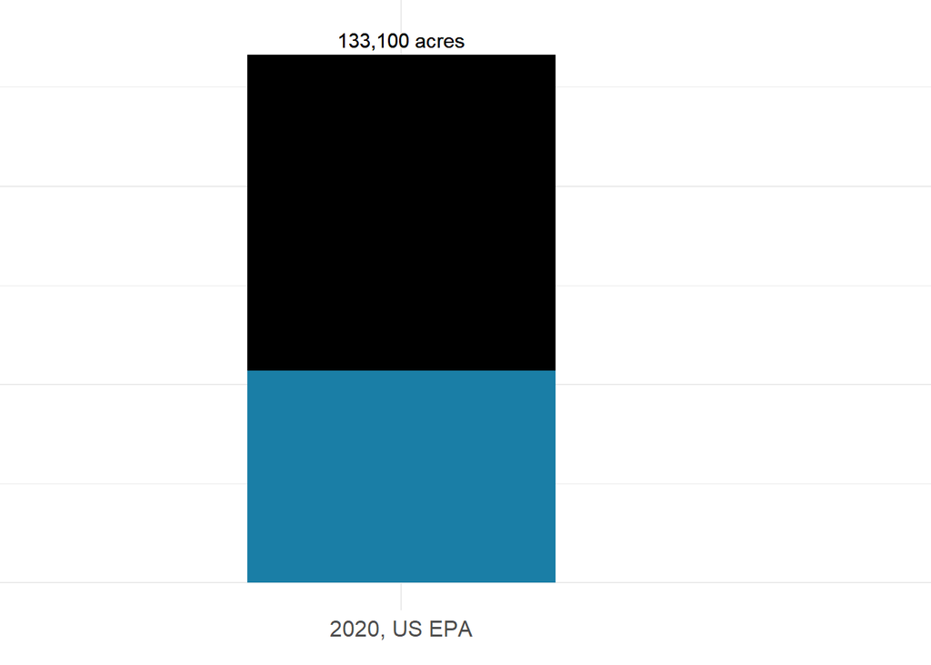

```r
plot_method0_b <- ggplot(table_method0_b)+
  geom_col(aes(x = Year, y = ac/1000, fill = source), width = 0.35)+
  geom_text(data = table_method0_b, aes(x = Year, y = total/1000, label = paste(comma(total), "acres")), vjust = -0.5)+
  scale_fill_manual(values = c("black", "#1A7EA6"))+
  ylab("acres")+
  theme_minimal()+
  guides(fill = "none")+
  ylim(c(0, 140))+
  xlab("")+
  ylab("")+
  theme(
    plot.margin = margin(0, 0, 0, -3, unit = "cm"),  # Adjust the right margin (3 cm in this case)
    axis.text.y = element_blank(),
    axis.text.x = element_text(size = 12)
  )
plot_method0_b
```

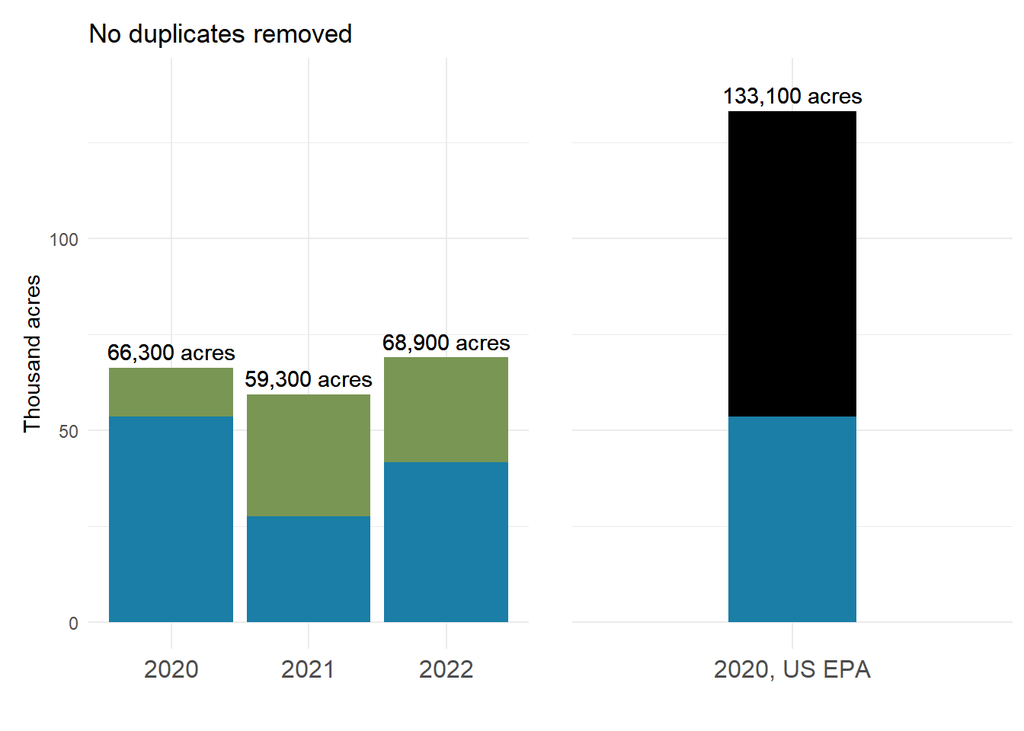

```r
(plot_method0_a | plot_method0_b)
```

```r
ggsave("figures/bar_chart_USEPA.png", width = 8, height = 5.5, units = c("in"))
```

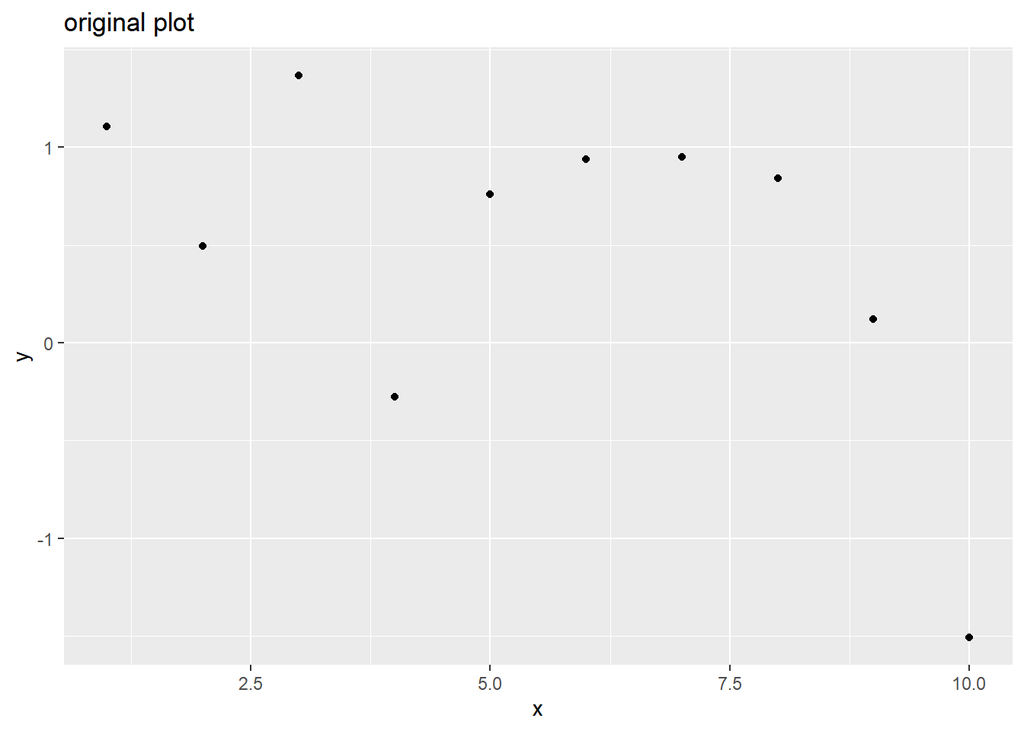

```r
# Create a basic scatter plot
data <- data.frame(
  x = 1:10,
  y = rnorm(10)
)

plot <- ggplot(data, aes(x, y)) +
  geom_point() +
  labs(title = "Scatter Plot")+
  ggtitle("original plot")
plot
```

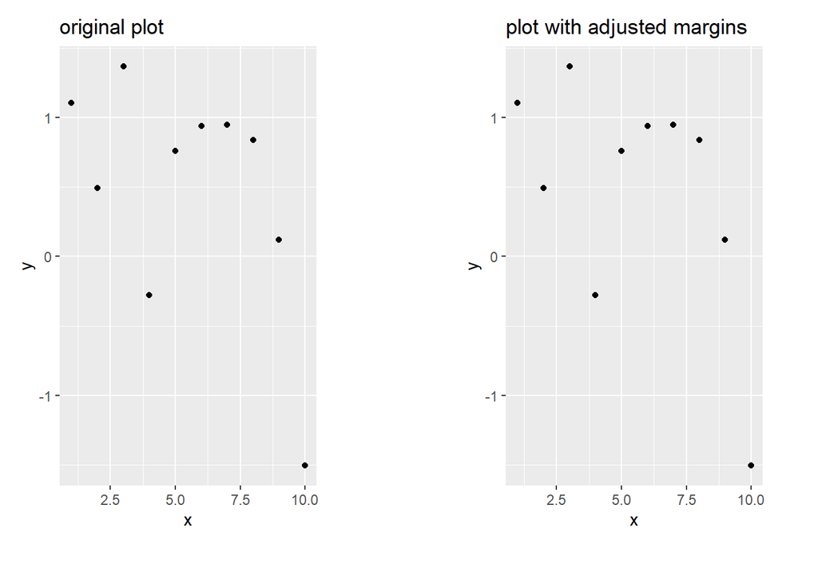

```r
# Adjust the width of the plot using theme() and plot.margin
plot2 <- plot +
  theme(
    plot.margin = margin(-1, 1, 1, 3, unit = "cm")  # Adjust the right margin (3 cm in this case)
  )+
  ggtitle("plot with adjusted margins")

(plot | plot2)
```

### Method 1

```r
table_method1 <- table_method1 %>%
  group_by(Year) %>%
  mutate(total = sum(acres) %>% round(-2))
table_method1
```

```
## # A tibble: 6 × 4
## # Groups:   Year [3]
##   Year  Data_source  acres total
##   <fct> <chr>        <dbl> <dbl>
## 1 2020  CalMapper   12859. 60700
## 2 2020  PFIRS       47876. 60700
## 3 2021  CalMapper   31811. 51900
## 4 2021  PFIRS       20125. 51900
## 5 2022  CalMapper   27296. 56500
## 6 2022  PFIRS       29163. 56500
```

### Method 2

```r
table_method2 <- table_method2 %>%
  group_by(Year) %>%
  mutate(total = sum(acres) %>% round(-2))
table_method2
```

```
## # A tibble: 6 × 4
## # Groups:   Year [3]
##   Year  Data_source  acres total
##   <fct> <chr>        <dbl> <dbl>
## 1 2020  CalMapper    9464. 61600
## 2 2020  PFIRS       52097. 61600
## 3 2021  CalMapper   30947. 51800
## 4 2021  PFIRS       20903. 51800
## 5 2022  CalMapper   21778. 57300
## 6 2022  PFIRS       35488. 57300
```

### Method 3

```r
table_method3 <- table_method3 %>%
  group_by(Year) %>%
  mutate(total = sum(acres) %>% round(-2))
table_method3
```

```
## # A tibble: 6 × 4
## # Groups:   Year [3]
##   Year  Data_source  acres total
##   <fct> <chr>        <dbl> <dbl>
## 1 2020  CalMapper    9104. 61000
## 2 2020  PFIRS       51869. 61000
## 3 2021  CalMapper   28662. 51700
## 4 2021  PFIRS       23078. 51700
## 5 2022  CalMapper   18830. 56900
## 6 2022  PFIRS       38033. 56900
```

```r
plot_method0 <- plot_method0+
  geom_text(data = table_method0, aes(x = Year, y = total, label = comma(total)), vjust = -0.5)+
  xlab("")
```

```r
plot_method2 <- plot_method2+
  geom_text(data = table_method2, aes(x = Year, y = total, label = comma(total)), vjust = -0.5)+
  xlab("")
```

```r
plot_method3 <- plot_method3+
  geom_text(data = table_method3, aes(x = Year, y = total, label = comma(total)), vjust = -0.5)+
  xlab("")
```

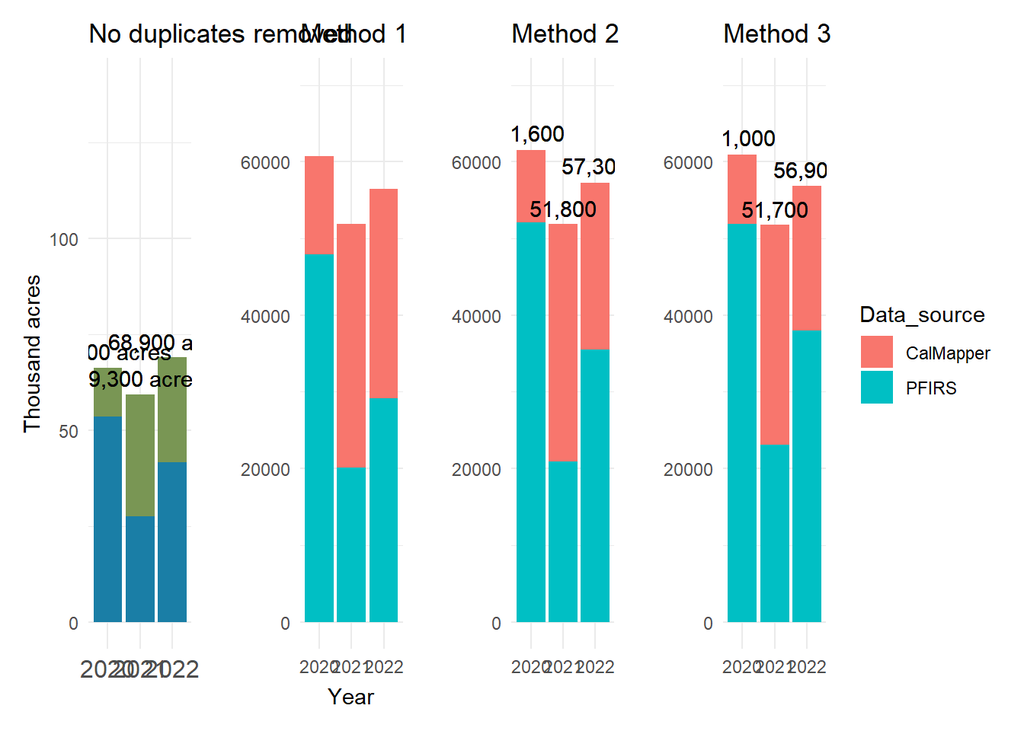

```r
all_plots <- (plot_method0_a | plot_method1 | plot_method2 | plot_method3)
all_plots
```

# Write duplicates to shapefile

```r
# dups_daily_esri <- dups_daily %>%
  # rename(Obj = TREATMENT_OBJECTIVE) %>%
  # select(-TREATMENT_SHAPE, -Data_source, -Data_source.1)
```

```r
# st_write(dups_daily_esri, dsn = "shapefiles", layer = "duplicates_final", driver = "ESRI Shapefile", delete_layer = T)
#
# dups_daily_point <- pfirs %>%
#   filter(ID_PFIRS_CT %in% dups_daily$ID_PFIRS_CT)
#
# st_write(dups_daily_point, dsn = "shapefiles", layer = "duplicates_POINT", driver = "ESRI Shapefile", delete_layer = T)
```